# Generating Random Sample

Inverse Transformation Method and Rejection Sampling

## Q1)

Create an algorithm (function) to generate data from the density function below by taking sample size $n=10^5$. (You should write your own function). After generating random sample do not forget to plot the sample and check sample statistics.

Let $X \sim N(0, 1)$, and the probability density function of |X| is;

$$f(x)= \frac{2}{\sqrt {2\pi}}e^{-\frac{x^2}{2}}, x>0$$

**a)** Can we generate data from this density function f(x) using inverse transformation method? Explain the reasoning. (5 pt)

To use inverse transformation method, we need to find quantile function (inverse of the CDF) and thus CDF of x. Since x distributed standard normal, f(x) does not have closed form of CDF.

**b)** Generate data from this density function f(x) using rejection sampling (acceptance and rejection method) by using g(x) function below. (15 pt)

**(HINT: Generate an exponential Y with mean 1 and generate U from uniform (0, 1) independent of Y)**

$$g(x)= \sqrt \frac{2e}{\pi}e^{-x}$$

Let applied the procedure,

**1. We choose density g(x) which is given above.**

**2. Find constant c;**

$$c= max\left(\frac{f(x)}{g(x)}\right)$$

$$\frac{d}{dx}\frac{f(x)}{g(x)} =0$$

$$\frac{d}{dx}\frac{\frac{2}{\sqrt {2\pi}}e^{-\frac{x^2}{2}}}{\sqrt \frac{2e}{\pi}e^{-x}}=0$$

$$\frac{d}{dx}e^{ \frac{-(x-1)^2}{2}}=0$$

$$\frac{d}{dx}e^{ \frac{-x^2+2x-1}{2}}=0$$

$$(-x+1)e^{-x^2+2x-1}=0$$

Exponential part cannot be zero, so (-x+1) should be zero to make $(-x+1)e^{-x^2+2x-1}$ equal to zero. Thus, x should be 1.

Finally,

$$x=1$$
when x=1, f(x)/g(x) = $e^{ \frac{-1^2+2*1-1}{2}}=e^0=1$

That is why **c=1** is chosen.

**3. Generate a random variable Y distributed as G(Y). —–> g(y)= rexp(1) uniform.**

**4. Generate a uniform random number U. —–> u= runif(1)**

5. If $U \leq \frac{\frac{2}{\sqrt {2\pi}}e^{-\frac{x^2}{2}}}{\sqrt \frac{2e}{\pi}e^{-x}}$ then accept set Y=X, else reject and go to step 3.

```r
rejection.sampling <- function(f, c, g, n) {
  set.seed(2022)
  k <- 0 # counter for accepted
  i <- 0 # number of iteration
  s <- c() #newly created random sample


  while (k < n) {
    x <- rexp(1, rate = 1)
    u <- runif(1)
    i <- i+1

    if (u <= f(x) / (c*g(x))) {
      k <- k + 1
      s[k] = x
    }

  }
  print(summary(s))
  return(s)

}


f <- function(x) 2/(sqrt(2*pi))*exp(-(x^2)/2)
g <- function(x) sqrt((2*exp(1))/pi)*exp(-x)
c <- 1 # an upper bound for f(x)/g(x)


result <- rejection.sampling(f, c, g, n=1000)
```

```
##     Min.  1st Qu.   Median     Mean  3rd Qu.     Max.
## 0.001999 0.314915 0.681193 0.817682 1.156503 3.759261
```

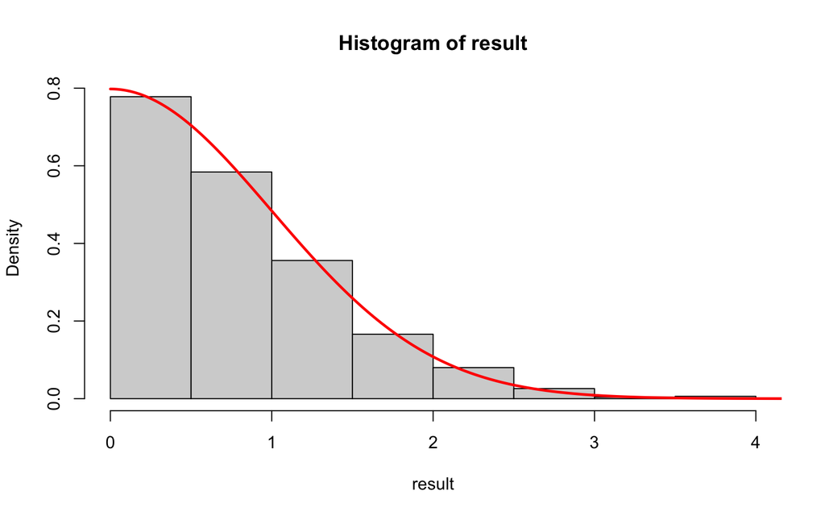

```r
hist(result, prob = T)

a<- seq(0,5,0.01)
points(a, 2/(sqrt(2*pi))*exp(-(a^2)/2) ,type = "l", col="red", lwd = 2.5)
```

**OR;**

```r
set.seed(2022)
n = 10^6
x = rexp(n, rate = 1)
u = runif(n)
s <- numeric(n)


# acceptance condition
s = x[u <= (2/(sqrt(2*pi))*exp(-(x^2)/2)) / (sqrt((2*exp(1))/pi)*exp(-x))]
length(s)
```

```
## [1] 760686
```

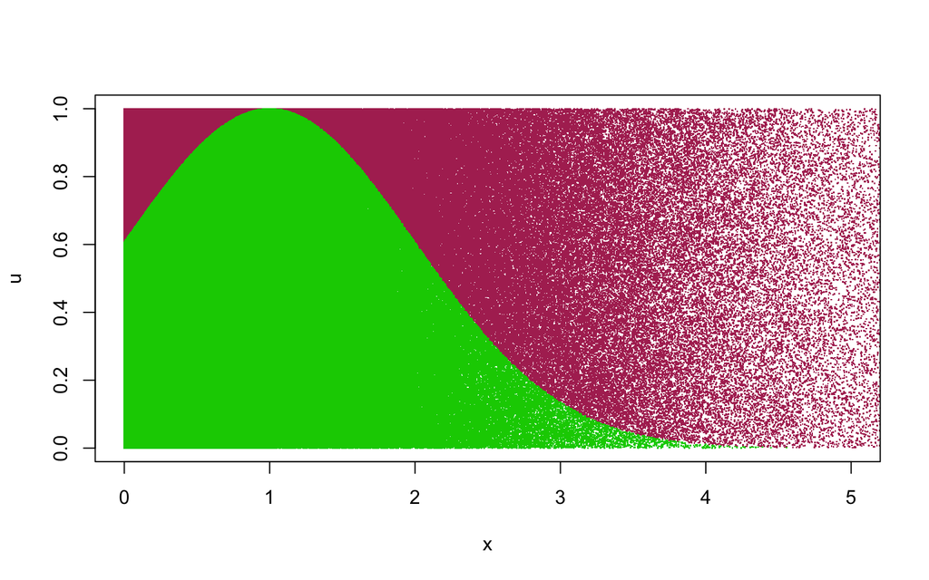

```r
plot(x, u, pch=".", col="maroon", xlim = c(0,5))
points(s, u[u <= (2/(sqrt(2*pi))*exp(-(x^2)/2)) / (sqrt((2*exp(1))/pi)*exp(-x))], pch=".", col="green3")
```

(Note: In some resources, they do not want to deal with c value. Thus, sometimes they just add c value in g(x) function as in this question. y is actually distributed exponential(1) and its pdf is $e^{-x}$. When we take g(x) as $e^{-x}$ c value will be $\sqrt \frac{2e}{\pi}$. In some questions they do not want to deal with c value and add g(x) function as $g(x)= \sqrt \frac{2e}{\pi}e^{-x}$.)

## Q2)

Let x is a random variable whose distribution is;

$$f(x)=\frac{1}{\pi s[1+ (\frac{x-\mu}{s})^2]},\ \text{where s>0 and x€}(-\infty,\infty)$$

Simulate f(x) with $\mu=5$ and $s=3$ by apply transformation methods using related distributions with f(x). Take sample size $n=10^4$ and use $y \sim N(0, 1)$ and $z \sim InvGamma(\frac{1}{2}, \frac{s^2}{2})$ to obtain f(x). (15 pt)

**(HINT: You should obtain $Cauchy(\mu,s)$ by using standard normal distribution and inverse gamma distribution).**

If Y ~ N(0,1) and $z \sim InvGamma(\frac{1}{2}, \frac{s^2}{2})$, then $X = \mu + Y \sqrt Z \sim Cauchy(\mu, s)$

To obtain Cauchy(5, 3) take $\mu=5$ and $s=3$.

```r
# install random number generator for inverse gamma
#install.packages("invgamma")
library(invgamma)

# rinvgamma(n, shape = , rate = )
```

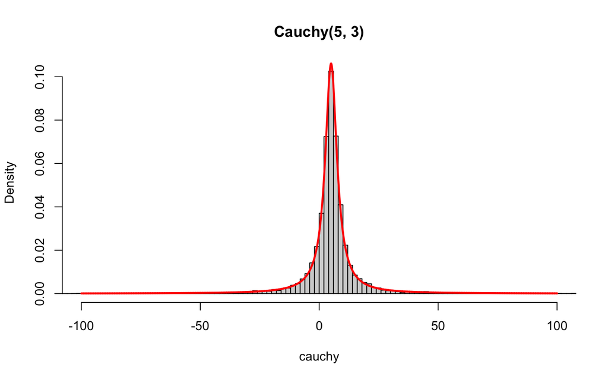

```r
library(invgamma)
set.seed(361)

n <- 10^4
mu <- 5
s <- 3

y <- rnorm(n, mean = 0, sd = 1)
z <- rinvgamma(n, shape = 1/2 , rate = (s^2)/2)

cauchy <- mu + y*sqrt(z)


hist(cauchy, prob=TRUE, xlim = c(- 100, 100),
     breaks = 100000,
     main = "Cauchy(5, 3)")
y = seq(-100,100,0.01)
lines(y,dcauchy(y,location = mu, scale = s),col="red",lwd = 2.5)
```

## Q3)

$$f(x)= \frac{1}{2}e^{-|x-\theta|}, -\infty<x<\infty$$

Write a **function** to generate random sample from the density function above using Inverse Transformation method by taking sample size $n=10^4$. Please take $\theta$ parameter as 2. After generating random sample do not forget to plot the sample and check sample statistics. (15 pt)

x belongs to double exponential distribution (laplace).

Remember that pdf of laplace distribution is;

$$f(x)= \frac{1}{2b}e^\frac{-|x-\mu|}{b}, -\infty<x<\infty$$
where $\mu$ is location parameter and b is scale parameter.

In our f(x) distribution b parameter is 1 and $\mu$ represented as $\theta$ which equals to 2.

Let take the cdf of that distribution; in this case when we take cdf of that distribution, we should look 2 cases;

1. when x > $\theta$
2. when $x \leq \theta$

CDF;

$$F(x) = \begin{cases}
\frac{1}{2}e^{(x-\theta)} & \text{if }x\leq \theta\\
1-\frac{1}{2}e^{-(x-\theta)} & \text{if }x>\theta\\
\end{cases}$$
$$E(X)=\theta=2\\ V(X)=2$$

$$F(x)^{-1} = U\ \text{where U~Uniform(0,1)}$$

$$F(U)^{-1} = \begin{cases}
\theta + In(2U) & \text{if }u\leq \frac{1}{2}\\
\theta-In(2-2U) & \text{if }u>\frac{1}{2}\\
\end{cases}$$

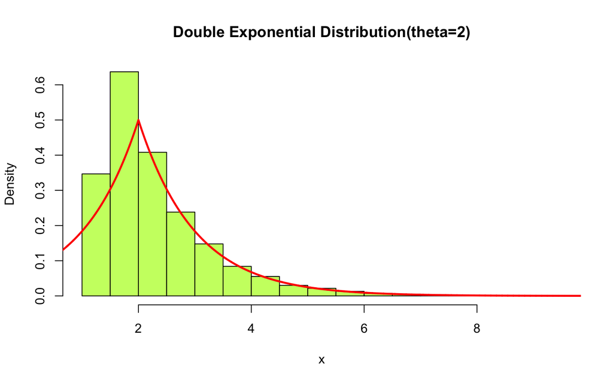

```
##    Min. 1st Qu.  Median    Mean 3rd Qu.    Max.
##   1.307   1.599   2.015   2.313   2.696   9.336
```

```r
double.exponentail <- function(n) {
  set.seed(361)
  x <- numeric(n)
  theta <- 2
  u <- runif(n)

    if(u <= (1/2)){
      x <- theta + log(2*u)

    } else if (u > (1/2)) {
      x <- theta - log(2-(2*u))
    }
      hist(x, prob = TRUE, main = 'Double Exponential Distribution(theta=2)', breaks=20, col="darkolivegreen1")
      y = seq(-10,10,0.001)
      lines(y, (1/2)*exp(-abs(y-theta)), col="red",lwd = 2.5)
      print(summary(x))
      return(x)
}

result<- double.exponentail(10^4)
```

Let see the pdf of double exponential distribution above using “d” function in R.

Please visit this page to see the function -> https://www.rdocumentation.org/packages/ExtDist/versions/0.6-4/topics/Laplace

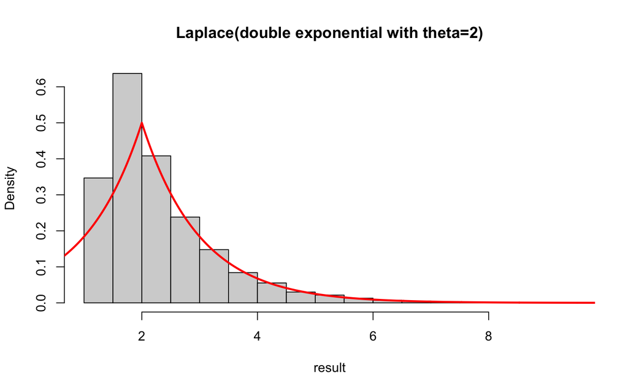

```r
library(ExtDist) #to obtain laplace distribution function

y = seq(-100,100,0.01)

hist(result, prob=TRUE,
     breaks = 20,
     main = "Laplace(double exponential with theta=2)")
lines(y, dLaplace(y, mu=2, b=1 ), col="red",lwd = 2.5)
```

## Q4)

Let f(x) is probability density function and non-zero on [-1, 1] and $f(x)/g(x) \leq c$. Simulate random sample from f(x) by taking y uniformly on [0, c]. You should use rejection sampling by taking sample size $n=10^4$ and remember that y $\sim g(y)$. (10 pt)

$$\ f(x) =
\begin{cases}
\frac{2}{\pi} \sqrt {1-x^2} & \text{if } -1 \leq x \leq 1 \\
0 & \text{} otherwise
\end{cases}$$

We solve this question assuming g(x) is 1. We should find the c value that maximize f(x). We can find that point by taking derivative of f(x) and then equalize it to 0.

$$f(x) \leq c$$
$$\frac{d}{dx}f(x) = \frac{2}{\pi}\frac{1}{2}\frac{1}{\sqrt {1-x^2}}(-2x) =\frac{-2x}{\pi \sqrt{1-x^2}}=0$$

There are 2 “x” values that make the derivative of f(x) zero, which are x=0 and x=1. Let’s see if f(x) reaches its maximum value in what x value. When x=1 it becomes f(x)=0, when x=0 it becomes f(x)=2/$\pi$. Maximum value that f(x) can take is 2/$\pi$. Thus, c=2/$\pi$.

When c=2/$\pi$, $g(x) = \frac{1}{2/\pi}\ on\ [0, 2/\pi]$

Set X=Y if U <= f(x)

```r
set.seed(2022)
n = 10^6

u = runif(n, 0, 2/pi)
x = runif(n, -1,1)
s =c()

s = x[u<=(2/pi)*sqrt(1-x^2)]
length(s)
```

```
## [1] 785823
```

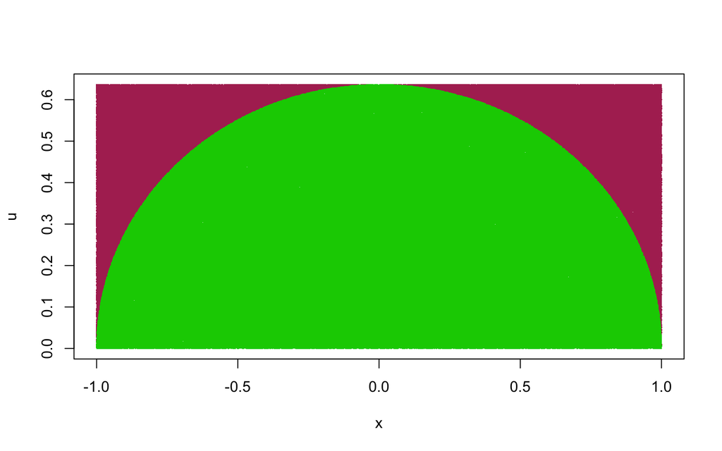

```r
plot(x,u, pch=".", col="maroon")
points(s,u[u<=(2/pi)*sqrt(1-x^2)], pch=".", col="green3")
```

**OR;**

```r
set.seed(2022)    # for reproducibility
n = 10^6
i <- 0 # iteration
k <- 0 # counter for accepted
s <- numeric(n) # random sample


while (k < n) {
  u = runif(1, 0, 2/pi) #since y distribute uniform on [0, c=2/pi]
  i <- i+1
  x = runif(1, -1,1) #since range of f(x) [-1, 1]
  if (u <= (2/pi)*sqrt(1-x^2)) {
    k <- k + 1
    s[k] <- x
  }
}
i;k;length(s)
```

```
## [1] 1273178
```

```
## [1] 1e+06
```

```
## [1] 1000000
```

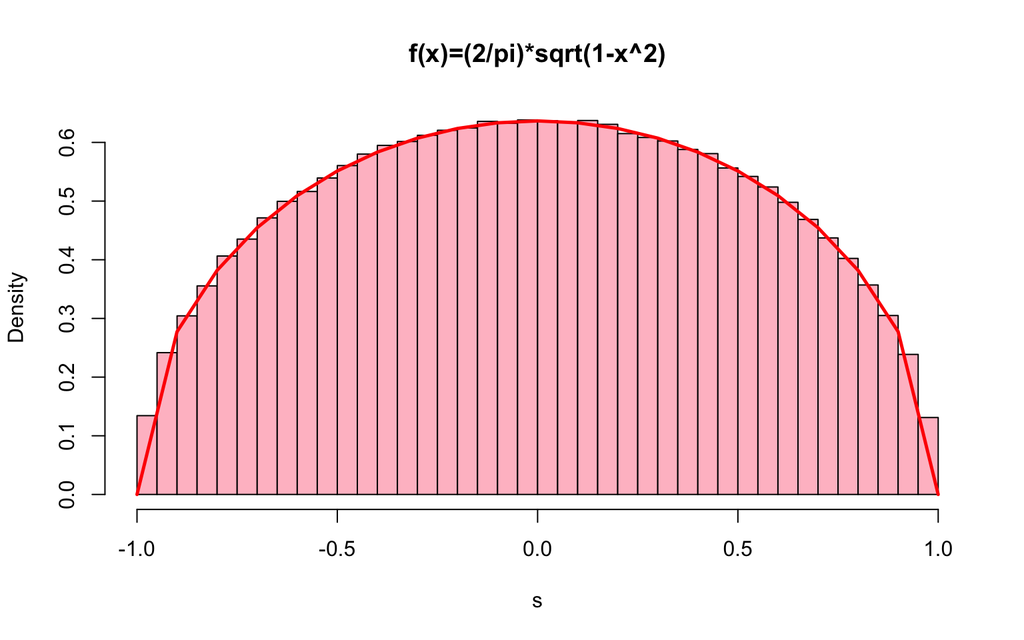

```r
hist(s, prob=T, breaks = 50, main="f(x)=(2/pi)*sqrt(1-x^2)", col="pink")
a <- seq(-1,1,0.1)
lines(a,(2/pi)*sqrt(1-a^2), col="red", lwd=2.5)
```

## Q5)

There is a manufacturing factory that produces light bulbs. This bulb manufacturing factory finds 4 out of every 80 light bulbs defective and you want to check that the first defective bulb will found **at least** the $6^{th}$ bulb.

**a)** Generate a random sample of size 1000 having from that distribution (firstly you should understand which distribution does this problem belong to) by using **inverse transform method**. (15 pt)

As the probability of the first defective light bulb needs to be determined hence, this is a geometric distribution.

This problem is belong to Geometric distribution. Pmf of the geometric distribution is;

$$p(X=x)=(1-p)^{x-1}p,\ where\ 0\leq p \leq1$$

$$p = 4 / 80 = 0.05$$

$$F(X) = 1- (1-p)^x,\ x=0,1,2,3,4,5,6$$

Let $u \sim Uniform(0,1)$

Transformation:

Set Y=X if,

$F(x-1) \leq U \leq F(x)$

= $(1- (1-p)^{x-1}) \leq U \leq (1- (1-p)^{x})$

= $(1-p)^{x-1} \leq 1- U \leq (1-p)^{x}$

Therefore,

$$X = \frac{log(1-U)}{log(1-p)}$$

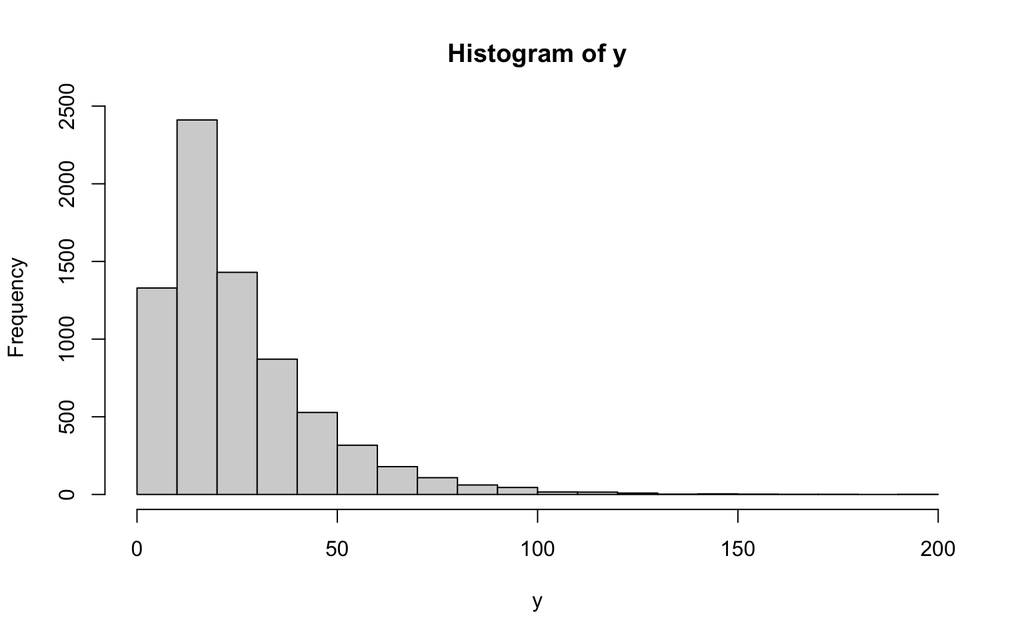

```r
n <- 10000
p <- 0.05
u<- runif(n) #generate uniform random variables

x<- log(1-u)/log(1-p) #apply inverse transformation method for geometric distribution
y<- x[x >= 6] # create a new vector for defective bulb will found **at least** the 6th bulb

hist(y)
```

**b)** Compute the mean and variance of the generated sample and compare the results with theoretical expectation and variance. (5 pt)

```r
geom_sample <- rgeom(n= 10000, p=0.05) #generate theoretical(real) geometric distribution
geom_sample_bigger_than_six <- geom_sample[geom_sample >= 6] # create a new vector for defective bulb will found **at least** the 6th bulb for real distribution

# compare the sample statistics of our sample and real geometric distribution

cat("mean of the generated geometric sample", mean(y),"\t", "variance of the generated geometric sample", var(y), "\n",
  "mean of the real geometric distribution", mean(geom_sample_bigger_than_six), "\t","variance of the real geometric distribution", var(geom_sample_bigger_than_six))
```

```
## mean of the generated geometric sample 25.53065   variance of the generated geometric sample 371.9107
##  mean of the real geometric distribution 24.70821     variance of the real geometric distribution 374.3151
```

## Q6)

Generate a random sample of size $n = 10^5$ from Beta(5,11). Use only runif(1) function to generate random variables. Density function of Beta($\alpha, \beta$) is

$$f(x; \alpha, \beta)=\frac{\Gamma(\alpha +\beta)}{\Gamma(\alpha)+\Gamma(\beta)}x^{\alpha-1}(1-x)^{\beta-1}, 0 \leq x \leq 1$$

Note that;

$$E(x)=\frac{\alpha}{\alpha+\beta}$$

$$V(x)=\frac{\alpha \beta}{(\alpha+\beta)^2(\alpha + \beta + 1)}$$

**a)** If both $\alpha$ and $\beta$ are integers, we can generate random numbers from the beta distribution with parameter $\alpha$ and $\beta$ by using the following algorithm: (15 pt)

- Generate $\alpha + \beta - 1$ number of Uniform Random Numbers; $U_1, U_2, ..., U_{\alpha + \beta - 1}$.
- Deliver $X = U_{(a)}$, which is the $a^{th}$ order statistic.

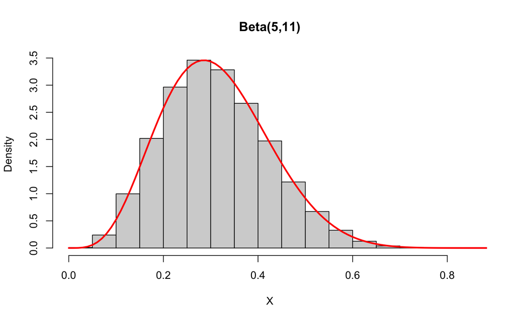

```r
n <- 10^5
alpha <- 5
beta <- 11
X <- numeric(n)


for(i in 1:n){
  u <- runif(n = alpha + beta - 1)
  sortu <- sort(u)
  X[i] <- sortu[alpha]
}

hist(X, prob = TRUE, main ="Beta(5,11)")
y=seq(0,1,0.01)
lines(y, dbeta(y, alpha, beta),col="red", lwd = 2.5)
```

**b)** Show that your sample has the properties of Beta(5,11) with visualization and sample statistics (5 pt).

```r
theoratical_mean <- alpha / (alpha + beta)
theoratical_var <- (alpha*beta) / ((alpha+beta)^2*(alpha+beta+1))

est_mean <- mean(X)
est_var <- var(X)

control <- matrix(round(c(theoratical_mean,theoratical_var,
est_mean,est_var),5), nrow = 2, byrow = T)
colnames(control) <- c("Mean","Variance")
rownames(control) <- c("Theoritical", "Estimated")
```

```r
library(dplyr)
library(kableExtra)

kbl(control) %>%
  kable_classic("striped", full_width = T) %>%
  column_spec(1, bold = T, background = "salmon")
```

|  | Mean | Variance |
| --- | --- | --- |
| Theoritical | 0.3125 | 0.01264 |
| Estimated | 0.3126 | 0.01256 |